# Prosper Loan Data Analysis by Preston Hall

> We will be using the data provided by Prosper Bank loans. Prosper Bank has facilitated more than $12 billion in loans to more than 770,000 people. You can find more information about Prosper Bank at their website.

> Introduction: (Needs work) I have worked in the financial industry for close to 10 years and have serviced and reviewed many loan documents. I am excited to analyze this data and discover new information.

> Now that I have the subset that I want to work with, I will clean it up a bit by removing a few of the NA values and adding factors to IncomeRange, Term and CreditGrade. IncomeRange and CreditGrade will ibe ordered factors.

# Univariate Plots Section

> **Tip**: In this section, you should perform some preliminary exploration of your dataset. Run some summaries of the data and create univariate plots to understand the structure of the individual variables in your dataset. Don’t forget to add a comment after each plot or closely-related group of plots! There should be multiple code chunks and text sections; the first one below is just to help you get started.

### Variables I will be working with

```
##  [1] "Term"                  "LoanStatus"
##  [3] "BorrowerRate"          "BorrowerState"
##  [5] "Occupation"            "EmploymentStatus"
##  [7] "CreditScoreRangeLower" "CreditScoreRangeUpper"
##  [9] "CreditGrade"           "OpenCreditLines"
## [11] "CurrentDelinquencies"  "AmountDelinquent"
## [13] "DebtToIncomeRatio"     "StatedMonthlyIncome"
## [15] "IncomeRange"           "MonthlyLoanPayment"
```

- Term
- LoanStatus
- BorrowerRate
- BorrowerState
- Occupation
- EmploymentStatus
- CreditScoreRangeLower
- CreditScoreRangeUpper
- CreditGrade
- OpenCreditLines
- CurrentDelinquencies
- AmountDelinquent
- DebtToIncomeRatio
- StatedMonthlyIncome
- IncomeRange
- MonthlyLoanPayment

### Borrower APR

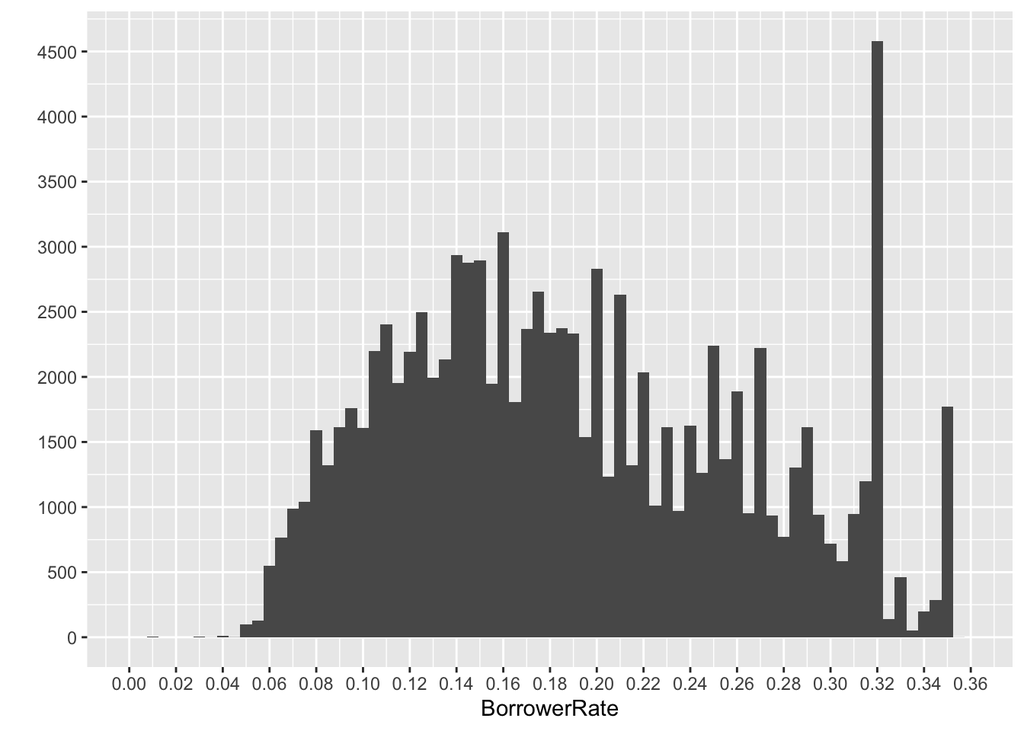

```
##    Min. 1st Qu.  Median    Mean 3rd Qu.    Max.
##  0.0000  0.1314  0.1800  0.1907  0.2492  0.3600
```

This graph is interesting as it is has a fairly normal distribution save for the rate at 32% the amount jumps up to over 4500.

### Stated Monthly Income

```
##    Min. 1st Qu.  Median    Mean 3rd Qu.    Max.
##       0    3333    4833    5720    6986  483333
```

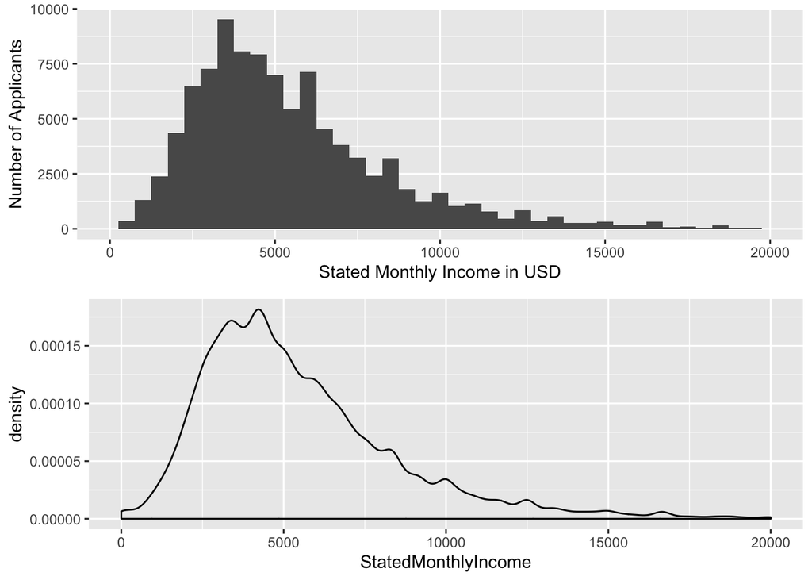

### Term

```
##    12    36    60
##  1415 73207 23143
```

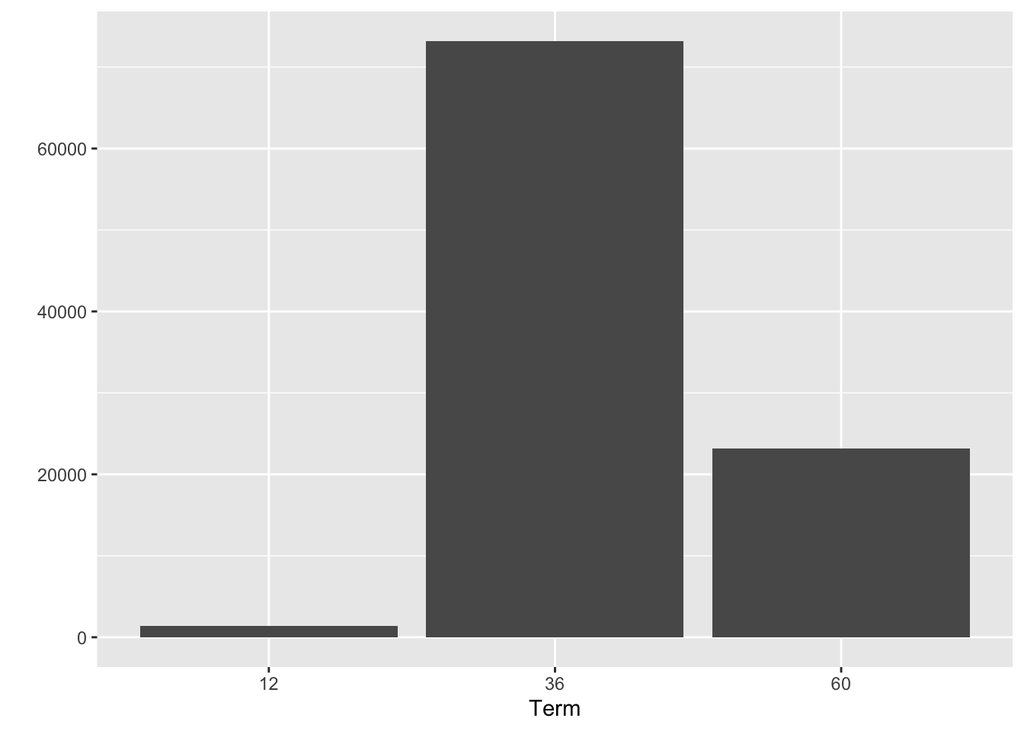

The types of loans fall into 3 different terms 12, 36, or 60 months. Or 1, 3, or 5 years respectively. The most common term is 3 years with over 73,000 loans.

### Credit Score

```
##    Min. 1st Qu.  Median    Mean 3rd Qu.    Max.
##   539.0   679.0   699.0   709.4   739.0   899.0
```

```
##    Min. 1st Qu.  Median    Mean 3rd Qu.    Max.
##   520.0   660.0   680.0   690.4   720.0   880.0
```

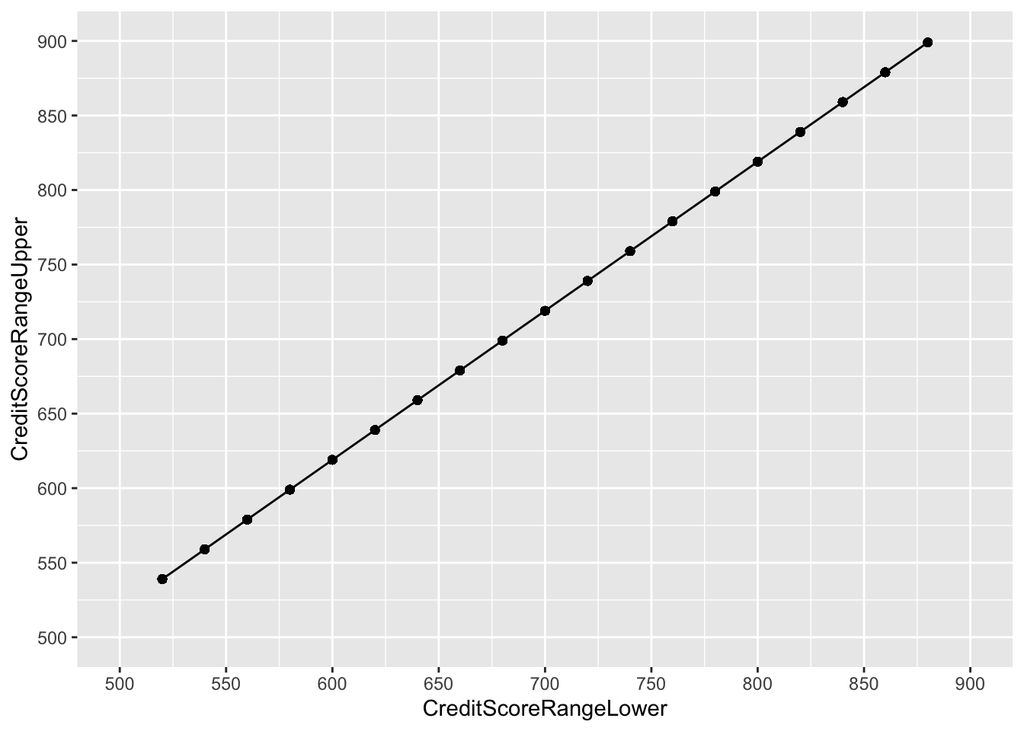

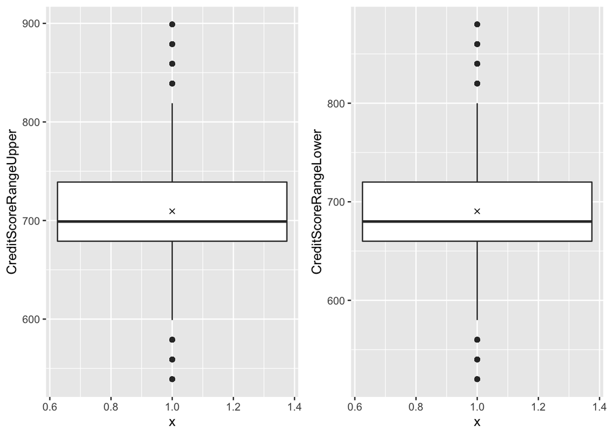

### Credit Score effect on Rate

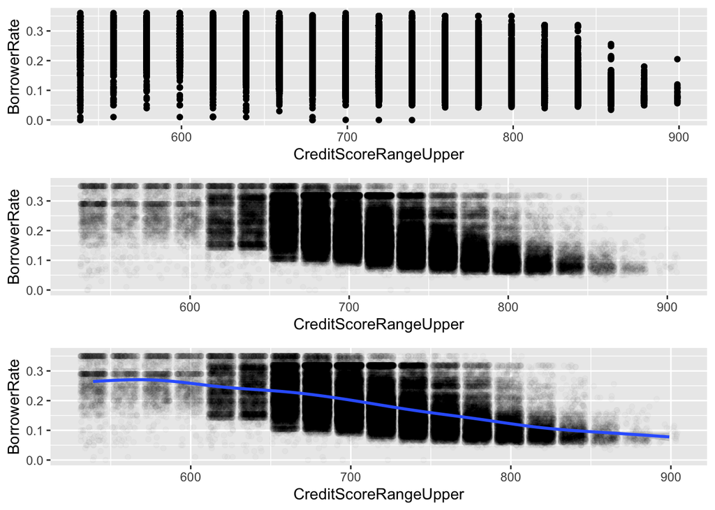

### CreditGrade

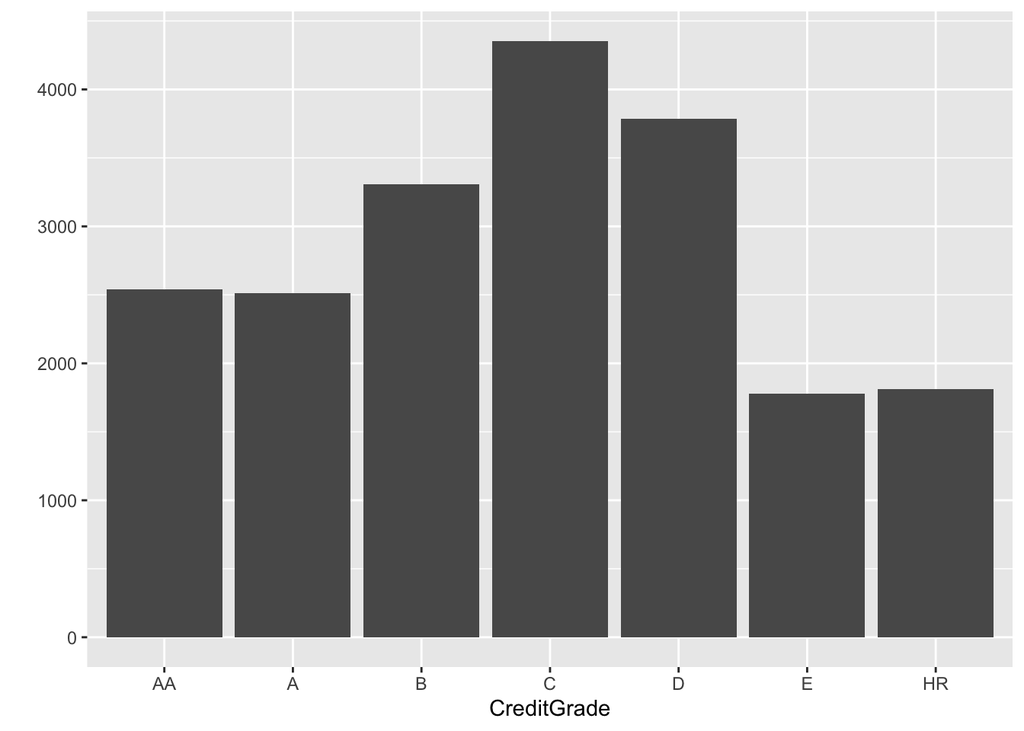

```
##    AA     A     B     C     D     E    HR    NC  NA's
##  2542  2510  3307  4354  3788  1776  1811     0 77677
```

> Customer are given a credit grade when provided a loan by Prosper Bank. AA would be the highest score with HR (High Risk) being at the lower end. Most customs have a score between B and D. I am not including NA values in this graph.

### Credit Lines

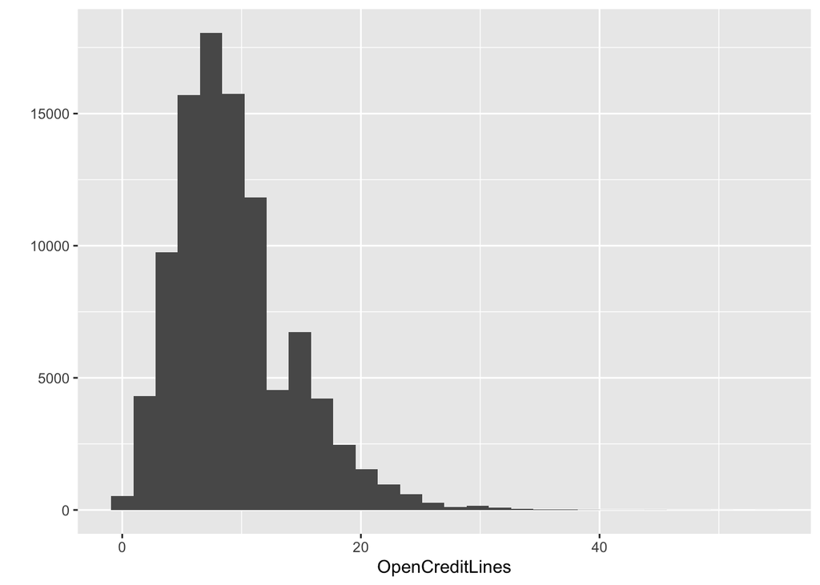

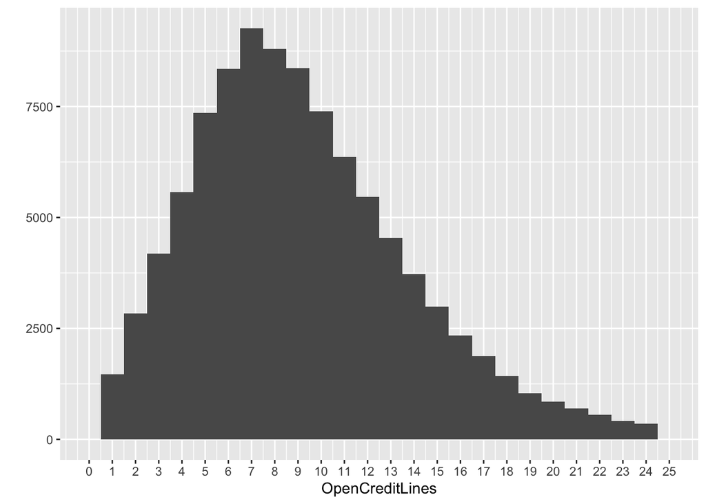

```
##    Min. 1st Qu.  Median    Mean 3rd Qu.    Max.
##   0.000   6.000   9.000   9.314  12.000  54.000
```

You can see from this graph that most people have around 7 open credit lines with a median of 9.

### Amount Delinquent

[output not shown]

# Univariate Analysis

> **Tip**: Now that you’ve completed your univariate explorations, it’s time to reflect on and summarize what you’ve found. Use the questions below to help you gather your observations and add your own if you have other thoughts!

### What is the structure of your dataset?

```r
dim(loanData)
```

```
## [1] 113937     81
```

```r
# structure(loanData)
```

### What is/are the main feature(s) of interest in your dataset?

### What other features in the dataset do you think will help support your

investigation into your feature(s) of interest?

### Did you create any new variables from existing variables in the dataset?

### Of the features you investigated, were there any unusual distributions?

Did you perform any operations on the data to tidy, adjust, or change the form  
of the data? If so, why did you do this?

# Bivariate Plots Section

> **Tip**: Based on what you saw in the univariate plots, what relationships between variables might be interesting to look at in this section? Don’t limit yourself to relationships between a main output feature and one of the supporting variables. Try to look at relationships between supporting variables as well.

# Bivariate Analysis

> **Tip**: As before, summarize what you found in your bivariate explorations here. Use the questions below to guide your discussion.

### Talk about some of the relationships you observed in this part of the

investigation. How did the feature(s) of interest vary with other features in  
the dataset?

### Did you observe any interesting relationships between the other features  
(not the main feature(s) of interest)?

### What was the strongest relationship you found?

# Multivariate Plots Section

> **Tip**: Now it’s time to put everything together. Based on what you found in the bivariate plots section, create a few multivariate plots to investigate more complex interactions between variables. Make sure that the plots that you create here are justified by the plots you explored in the previous section. If you plan on creating any mathematical models, this is the section where you will do that.

# Multivariate Analysis

### Talk about some of the relationships you observed in this part of the

investigation. Were there features that strengthened each other in terms of  
looking at your feature(s) of interest?

### Were there any interesting or surprising interactions between features?

### OPTIONAL: Did you create any models with your dataset? Discuss the

strengths and limitations of your model.

# Final Plots and Summary

> **Tip**: You’ve done a lot of exploration and have built up an understanding of the structure of and relationships between the variables in your dataset. Here, you will select three plots from all of your previous exploration to present here as a summary of some of your most interesting findings. Make sure that you have refined your selected plots for good titling, axis labels (with units), and good aesthetic choices (e.g. color, transparency). After each plot, make sure you justify why you chose each plot by describing what it shows.

### Plot Three

# Reflection

> **Tip**: Here’s the final step! Reflect on the exploration you performed and the insights you found. What were some of the struggles that you went through? What went well? What was surprising? Make sure you include an insight into future work that could be done with the dataset.

> **Tip**: Don’t forget to remove this, and the other **Tip** sections before saving your final work and knitting the final report!